# Лабораторная работа 3

# Задание 9

Источник данных - reforest.xlsx Удалите строки, в которых есть пропущенные значения и приведите данные к формату tidydata. Отобразите динамику лесовосстановления по годам с помощью линейного графика для любого из федеральных округов, обозначив субъекты федерации разными цветами. Подпишите значения на графике. Отрегулируйте местоположение подписей так, чтобы рисунок был максимально наглядным. Придумайте новые назания графика и осей.

Загружаем нужные данные:

```r
library("readxl")
f <- file.choose()  # reforest.xlsx
data <- read_excel(f)
```

Удаляем ненужные строки, содержащие пустыезначения (NA):

```r
for (i in 2:length(names(data))) {
  data[[i]] <- as.numeric(data[[i]])
}
data_complete_cases <- data[complete.cases(data),]
```

Данные приводим к виду tidydata, после чего выбирается интересуюющий регион (в данном случае - Северо-Западный федеральный округ):

```r
library("tidyr")
library("dplyr")
new_data <- data_complete_cases %>%
  pivot_longer(cols = !Region, names_to = "Year", values_to = "Reforest_value") %>%
  slice(161:208)
```

Наконец, отрисоваваем искомая информация:

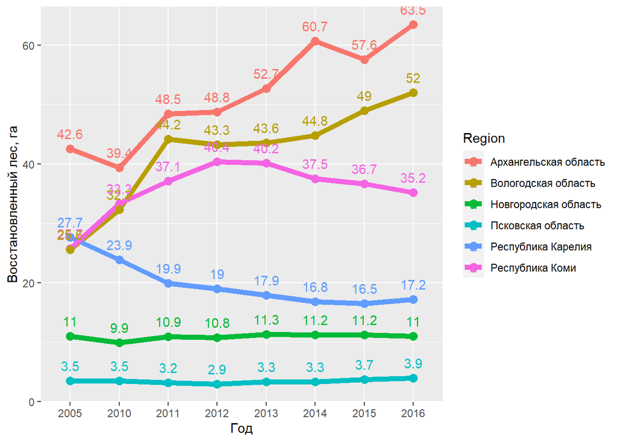

```r
library(ggplot2)
ggplot(new_data, aes(Year, Reforest_value, color = Region)) +
  geom_line(aes(group = Region), size=2) +
  geom_point(aes(group = Region), size=3) +
  geom_text(aes(label = Reforest_value, vjust = -1,)) +
  # theme(legend.position=c(0.1, 0.85)) +
  xlab("Год") +
  ylab("Восстановленный лес, га")
```

# Задание 14

Файлы data2.csv, data1.txt. Объедините data.frames по идентификаторам сортов. Исключите те сорта, для которых есть пропущенные значения. Для всех наблюдаемых величин из файла test_data1.txt (из первого дз), в которых содержится не более 80% пропущенных значений нарисовать гистограммы. Найтите корреляции Пирсона для количественных переменных. Постройте тепловую карту (heatmap).

Загружаем необходимые данные:

```r
f <- file.choose()  # data1.txt
data_1 <- read.table(f, header = TRUE, sep = " ")
data_1 <- data.frame(t(data_1))
f <- file.choose()  # data2.csv
data_2 <- read.csv(f)
```

После чего загружженую информацию объединяем в единый датафрейм по идентификатору сорта:

```r
tmp_names <- data_2$X
data_2[[1]] <- NULL
rownames(data_2) <- tmp_names

total_data <- t(rbind(data_1, data_2))
total_data <- data.frame(total_data[complete.cases(total_data), ])
```

Немного отвлёчемся. Обратимся к данным из 1-ого задания и немного преобразуем рассмариваемый датафрейм:

```r
f <- file.choose()  # test_data_01.csv
data <- read.csv(f)
fix_column <- function(column) {
    res <- as.numeric(column)
    return(res)
  }
data <- data.frame(apply(data, 1:2, fix_column))
```

```r
na_df <- apply(data, 2, function(x) length(which(is.na(x))))
data_len <- dim(data)[1]

for (name in names(na_df))
  if (na_df[[name]] / data_len  > 0.8)
    data[[name]] <- NULL
```

Преобразуем этот датафрейм к виду tidydata…

```r
tidy_data<- data %>% pivot_longer(names(data), names_to = "Type", values_to = "Value")
tidy_data <- tidy_data[complete.cases(tidy_data), ]
```

…и построим гистограммы:

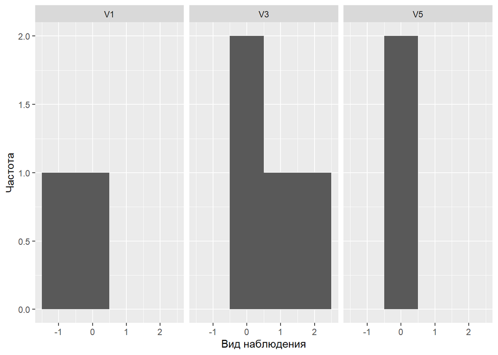

```r
ggplot(tidy_data, aes(Value)) +
    geom_histogram(binwidth=1) +
    facet_wrap(~Type) +
    xlab("Вид наблюдения") +
    ylab("Частота")
```

Вернемся к изначальной total_data и наёдем матрицу корелляции, состоящую из коэффииентов корреляции Пирсона, после чего изобразим её в виде тепловой карты:

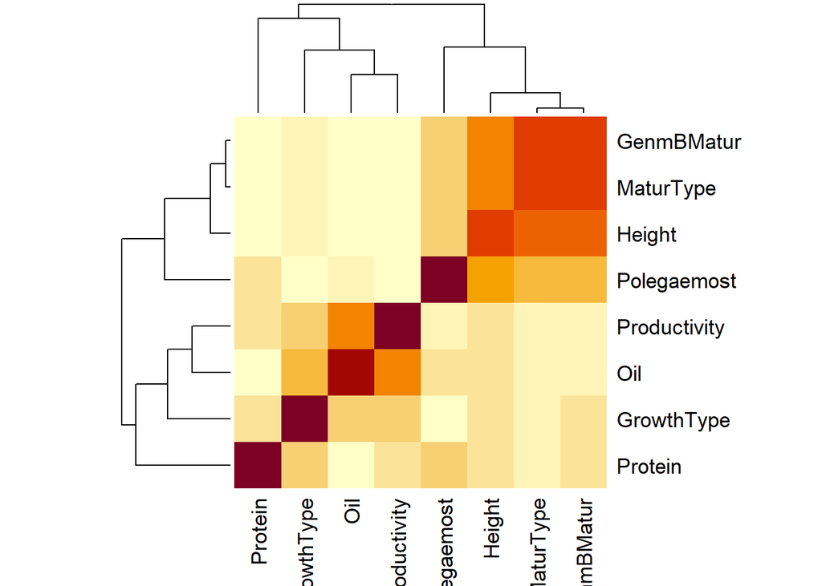

```r
my_colors <- colorRampPalette(c("cyan", "deeppink3"))
cor_matrix <- cor(total_data)
heatmap(cor_matrix)
```

# Доп задание shniy

В качестве упражнения с shiny был выбран визулизатор таблицы total_data из предыдущего задания с возможностью решулирования количества отображаемых столбцов и строк

Предзагрузка данных:

```r
f <- file.choose()  # "data/data1.txt"
data_1 <- read.table(f, header = TRUE, sep = " ")
data_1 <- data.frame(t(data_1))

f <- file.choose() # "data/data2.csv"
data_2 <- read.csv(f)
tmp_names <- data_2$X
data_2[[1]] <- NULL
rownames(data_2) <- tmp_names

total_data <- data.frame(t(rbind(data_1, data_2)))
```

Интерефейс:

```r
library(shiny)

ui <- fluidPage(
  titlePanel("Merged data visualization"),
  sidebarLayout(
    sidebarPanel(
        checkboxGroupInput("show_vars", "Columns in \"total_data\" table to show:",
                           names(total_data), selected = names(total_data))
    ),
    mainPanel(
      tabsetPanel(
        id = 'dataset',
        tabPanel("Data from task 14", DT::dataTableOutput("mytable1")),
      )
    )
  )
)
```

Сервер:

```r
server <- function(input, output) {
  output$mytable1 <- DT::renderDataTable({
    DT::datatable(total_data[, input$show_vars, drop = FALSE])
  })
}
```

Запуск приложения в rmd невозможен, поэтому рекомендуется запуск непосредственно с помощью IDE (будь то RStudio или PyCharm с соответствующим расширением для работы с R). Исходный файл “Shiny.r” находится в каталоге source.